# CS 7324 Lab 6

## Francesco Trozzi (47779944) - George Sammit (04010135) - Megan Simons (46334773)

# Preparation

## Globals

```python
# Usually only expand the data once
RAW_DATA_EXPANSION = True
TRANSFER_EXPANSION = True
MLP_COMPARISON_EXPANSION = True

# Number of images/classification
MAX_IMAGES_PER_CLASSIFICATION = 500 # 2000

# Tweaks for testing
EPOCHS = 50 # 50
DATA_SPLITS = 5 # 10
BATCH_SIZE = 32
PATIENCE = 10

# The classifications
CLASSIFICATIONS = { 'cheetah' : 0, 'jaguar' : 1, 'tiger' : 2, 'hyena' : 3}
NUM_CLASSES = 4

# For statistical comparison
ALPHA = 0.05
```

## Imports

```python
import warnings; warnings.simplefilter('ignore')

import os
import random
import numpy as np
import tensorflow.keras.backend as K
import matplotlib.pyplot as plt
import seaborn as sns

from time import time
from skimage import io
from skimage.io import imshow
from skimage.transform import resize
from sklearn import metrics as mt
from sklearn.model_selection import ShuffleSplit, train_test_split
from sklearn.metrics import roc_curve, auc
from statsmodels.stats.contingency_tables import mcnemar

from tensorflow.keras.preprocessing import image
from tensorflow.keras.preprocessing.image import ImageDataGenerator
from tensorflow.keras.models import Sequential, Model, Sequential
from tensorflow.keras.utils import to_categorical
from tensorflow.keras.callbacks import EarlyStopping, Callback
from tensorflow.keras.regularizers import l2
from tensorflow.keras.layers import Conv2D, MaxPooling2D, Reshape, Dense, Activation, Input, Dropout, Embedding, Flatten, Concatenate, Add, Conv2D, MaxPooling2D
```

## The Data

We are using the same dataset from Lab 2 which is https://www.kaggle.com/iluvchicken/cheetah-jaguar-and-tige. It presents 4,000 400x400 color images of cheetahs, jaguars, tigers, and hyenas. There are 1,000 images of each type of animals. These images are taken in various settings, at different angles, with various profiles, and do not necessarily expose the entire animal. They also include pups, males, and females. These aspects may be seen in the following examples from the data set (two cells below)

### Data Augmentation

Used to take the raw images, and change them slightly (some minor rotations, etc.) to create new images. We opt for pretty basic changes in the images. Our images are of animals in the wild, so vertical flipping is likely to generate an unrealistic image. We also don't want to rotate too much to preserve nature, e.g. trees don't normally grow at a 20-degree angle. Finally, we want to ensure that we don't move the animal out of the image, e.g. cut off a head.

```python
def change_feature():
    change = random.randint(0,2)
    if change > 0:
        return True
    return False
```

```python
def get_classifier(string_name):
    assert string_name in CLASSIFICATIONS.keys()
    return CLASSIFICATIONS[string_name]

def decode_classifier(classifier):
    for text in CLASSIFICATIONS.keys():
        if CLASSIFICATIONS[text] == classifier:
            return text
```

```python
def augment_data(save_to_dir):

    base_dir = os.path.join('.', 'raw_images')
    image_files = os.listdir(base_dir)

    # There is a small chance that no changes will occur which we accept
    random = np.random.default_rng()

    print("Creating images in {}...".format(save_to_dir))
    loop_count = 0
    for image_file in image_files:
        loop_count += 1

        if loop_count % 50 == 0:
            print("  {} images created".format(int(loop_count/50)))

            # Rotate up to 12 degrees
            rotation = np.random.randint(0,13) if change_feature() else 0

            # Shift in the range [0.05, 0.20)
            width_shift = np.random.uniform(0.05,0.2) if change_feature() else 0.0
            height_shift = np.random.uniform(0.05,0.2) if change_feature() else 0.0

            # Change in the range [0.05, 0.2)
            shear = np.random.uniform(0.05,0.2) if change_feature() else 0.0
            zoom = np.random.uniform(0.05,0.2) if change_feature() else 0.0

            # Don't rescale much
            rescale = 1./np.random.randint(240,260)if change_feature() else 0.0

            # Flip randomly
            flip = change_feature()

            image = io.imread(os.path.join(base_dir, image_file), as_gray=False)
            image = image.reshape((1,) + image.shape)
            classifier = image_file.split('_')[0] # 0 - animal, 1 = unimportant parts
            image_generator = ImageDataGenerator(rotation_range = rotation,
                                                 horizontal_flip = flip,
                                                 width_shift_range = width_shift,
                                                 height_shift_range = height_shift,
                                                 rescale = rescale,
                                                 shear_range = shear,
                                                 zoom_range = zoom,
                                                 fill_mode = 'constant', # Nearest test to blur the animals
                                                 cval=1)
            for _ in image_generator.flow(image,
                                          batch_size = 1,
                                          save_to_dir = save_to_dir,
                                          save_prefix = classifier,
                                          save_format = 'jpeg'):
                # Only one augmentation per image
                break

    print("Done")
    print("{} images created".format(int(loop_count/50)))
```

### Data Expansion

We decided to do the expansion once prior to splitting the data, and do it manually rather than during the model fitting in real-time.

```python
if RAW_DATA_EXPANSION:
    augment_data('expanded_images')
```

```
Creating images in expanded_images...
  1 images created
  2 images created
  3 images created
  4 images created
  5 images created
  6 images created
  7 images created
  8 images created
  9 images created
  10 images created
  11 images created
  12 images created
  13 images created
  14 images created
```

[output cut: 68 more lines]

### MLP Comparison Data

For the MLP comparison data we pre-generated (3799 images) from the raw images, we are adding 80 for exercise sake.

Create a set of data to use during the MLP comparison part. We're using a shuffle split, so we're doing this to avoid testing on the same data that we trained on.

```python
if MLP_COMPARISON_EXPANSION:
    augment_data('mlp_comp_images')
```

```
Creating images in mlp_comp_images...
  1 images created
  2 images created
  3 images created
  4 images created
  5 images created
  6 images created
  7 images created
  8 images created
  9 images created
  10 images created
  11 images created
  12 images created
  13 images created
  14 images created
```

[output cut: 68 more lines]

### Transfer Learning Data

Similar to above, we're creating a dataset that the model has not seen.

```python
if TRANSFER_EXPANSION:
    augment_data('transfer_images')
```

```
Creating images in transfer_images...
  1 images created
  2 images created
  3 images created
  4 images created
  5 images created
  6 images created
  7 images created
  8 images created
  9 images created
  10 images created
  11 images created
  12 images created
  13 images created
  14 images created
```

[output cut: 68 more lines]

### Load the main image dataset

```python
def load_images(directories):
    images = []
    classifications = []

    processed = {}
    for classifier in CLASSIFICATIONS.values():
        processed[classifier] = 0

    # Images are stored in the directory as follows:
    # ./raw_image
    #   -> <animal>_<image#>_<tag>.jpg  where the tag is resized (training) or val_resized (validtion).
    # We just lump them by animal and split into training/test ourselves.
    for directory in directories:

        base_dir = os.path.join('.', directory)
        image_files = os.listdir(base_dir)

        print("\nLoading images from {}...".format(directory))
        for image_file in image_files:
            if len(images) % 100 == 0:
                print("  {} images processed".format(len(images)))

            classifier = get_classifier(image_file.split('_')[0]) # 0 - animal, 1 = unimportant parts
            if processed[classifier] < MAX_IMAGES_PER_CLASSIFICATION:
                try:
                    images.append(io.imread(os.path.join(base_dir, image_file), as_gray=False))
                    classifications.append(classifier)
                    processed[classifier] += 1
                except Exception as ex:
                    print("Skipping " + file + " " + str(ex))

        num_images_processed = sum(processed.values())
        print("Done")
        print("{} images available".format(num_images_processed))

    return images, classifications
```

```python
images, classifications = load_images(['raw_images', 'expanded_images'])
```

```
Loading images from raw_images...
  0 images processed
  100 images processed
  200 images processed
  300 images processed
  400 images processed
  500 images processed
  600 images processed
  700 images processed
  800 images processed
  900 images processed
  1000 images processed
  1100 images processed
  1200 images processed
  1300 images processed
```

[output cut: 2073 more lines]

### Normalization

```python
classifications = np.array(classifications , dtype=int)
print("Classifications array shape: {}".format(classifications.shape))

images = np.array(images, dtype=float)
max = images.max()
print("\nBefore normalization - Min: {} Max {}".format(images.min(), max))
images /= max
print("After normalization - Min: {} Max {}".format(images.min(), images.max()))
print("Images array shape: {}".format(images.shape))
```

```
Classifications array shape: (2000,)

Before normalization - Min: 0.0 Max 255.0
After normalization - Min: 0.0 Max 1.0
Images array shape: (2000, 400, 400, 3)
```

### OHE

```python
classifications_ohe = to_categorical(classifications, NUM_CLASSES)
```

### Image Samples

```python
def show_images(image_indexes, images, caption, label_image=False):
    """Show the images that correspond to the input indexes"""
    fig = plt.figure(figsize=(15, 4.6))
    fig.suptitle(caption)
    num_images_to_show = len(image_indexes)
    for plot_index in range(num_images_to_show):
        pic_index = image_indexes.pop()
        plt.subplot(1, num_images_to_show, plot_index + 1)
        plt.imshow(images[pic_index])
        if label_image:
            plt.title("Image " + str(plot_index))
```

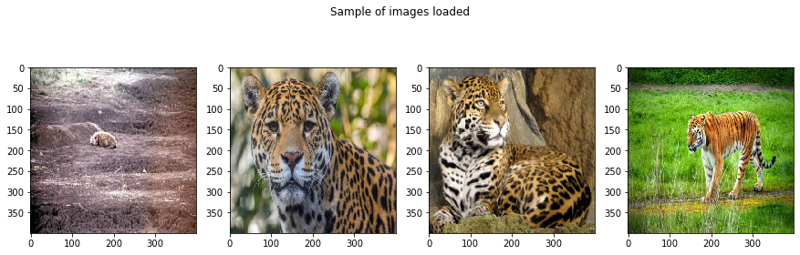

```python
import random

def get_random_indexes(num_indexes, array):
    """Returns a set of 4 unique random indexes over the input array"""
    rands = set()
    while len(rands) < num_indexes:
        rands.add(random.randint(0, len(array)-1))
    return rands

def show_random_images(num_to_show, images, caption):
    """Displays four random images from the input list"""
    rands = get_random_indexes(num_to_show, images)
    show_images(rands, images, caption)

show_random_images(4, images, "Sample of images loaded")
```

Note that if you see black in the images above, it is likely a result of image augmentation. We found that using "nearest" tended to blur the image, especially when it was part of the animal, so we chosed to just black-fill shifting/rotation. The first image above is a clear example of how difficult this dataset is.

## Metrics

As mentioned in a previous lab report the ability to classify animals in the wild has several potential applications. One such application could be facilitated by the use of outdoor cameras. For example so-called “urban” coyotes pose real threats to pets in Texas (https://texashillcountry.com/coyotes-texas-dangerous/). Strategically mounting cameras that have the ability to differentiate a coyote from a dog and alert appropriately could be valuable to local animal control agencies. In this application, misclassifications would pose a mere nuisances. We are going to build our model evaluation criteria based on this application.

As mentioned as a misclassification would represent just a nuisances, while a correct classification of the animal in order to assess potential danger shall be a priority. For this reason recall represents a good metric. However, realistically if the camera is installed in the premises of a house it is going to see domestic animals way more frequently, if recall is used as a metric this might result in calling the local authorities multiple time a day, which will probably result in them to ignore your calls. We call potential pitfull as “The Boy Who Cried 'Wolf' scenario." We then decide to sprinkle some precision into the evaluation metric, to make the model value more actual positives. We therefore use a custom F1 score, which represented a balance between the two metrics. The f1 score that we are going to implement is goint to still give more preference to recall while trying to minimize the false positives.

```python
def custom_f1(y_true, y_pred): #taken from old keras source code
    epsilon = np.finfo(float).eps
    beta=2
    true_positives = K.sum(K.round(K.clip(y_true * y_pred, 0, 1)))
    possible_positives = K.sum(K.round(K.clip(y_true, 0, 1)))
    predicted_positives = K.sum(K.round(K.clip(y_pred, 0, 1)))
    precision = true_positives / (predicted_positives + epsilon)
    recall = true_positives / (possible_positives + epsilon)
    f1_val = (1+(beta**2))*(precision*recall)/(((beta**2)*precision)+recall+epsilon)
    return f1_val
```

The when the beta is higher then 1, the custom f1 value recall more then precision. The formula for the custom f1 was taken from: https://towardsdatascience.com/the-5-classification-evaluation-metrics-you-must-know-aa97784ff226

#### Utility for comparing models

```python
def compare_comps(comps):
    for i in range(len(comps)):
        for j in range(i+1, len(comps)):
            table = table_compiler(comps[i], comps[j])
            result = mcnemar(table, exact=False)
            print(models_titles[i]+' vs '+ models_titles[j])
            print('statistic=%.3f, p-value=%.3f' % (result.statistic, result.pvalue))
            if result.pvalue > ALPHA:
                print('No meaningful difference in performance (fail to reject H0)')
                print('-----------------------------------------------------------')
                print()
            else:
                print('Meaningful difference in performance (reject H0)')
                print('------------------------------------------------')
                print()
```

## Train/Test Split

When normal training/test split is done, the split is done randomly and places the first X% of data in training and places the remaining X% of data in testing. Since we cannot fully ensure our training/test split is done randomly, there might end up being some bias. If one class ended up fully in training or testing, this would lead to our model not being able to learn and classify each animal properly. Therefore, to ensure total randomization between the 4 equal classifications, we will use shuffle splits. This way, we can decrease the likelihood of bias occurring in the split by decreasing the likelihood that the classes will not be split well. Since the number of images is equal among classes, once the shuffling has occurred we can do the usual 0.8/0.2 train/test split.

```python
rs = ShuffleSplit(n_splits=DATA_SPLITS, test_size=.2, random_state=0)
rs.get_n_splits(images)
iteration = 0
for train_index, test_index in rs.split(images):
    print("Split #{}: Training samples = {} Testing samples = {}" .format(iteration,
                                                                          len(train_index),
                                                                          len(test_index)))
    iteration += 1
```

```
Split #0: Training samples = 1600 Testing samples = 400
Split #1: Training samples = 1600 Testing samples = 400
Split #2: Training samples = 1600 Testing samples = 400
Split #3: Training samples = 1600 Testing samples = 400
Split #4: Training samples = 1600 Testing samples = 400
```

# Modeling

### Utilities

```python
def plot_history(histories, to_plot):
    fig, axs = plt.subplots(1,2, sharey=True, figsize=(12,6))
    for history in histories:
        axs[0].plot(history.history[to_plot])
        axs[1].plot(history.history['val_'+to_plot])

    axs[0].set_title('Training ')
    axs[1].set_title('Validation')
    for ax in axs.flat:
        ax.set(xlabel='Epochs')

    plt.suptitle('Model ' + to_plot.capitalize())
    plt.tight_layout()
    plt.show()

def plot_loss(histories):
    plot_history(histories, 'loss')

def plot_custom_f1(histories):
    plot_history(histories, 'custom_f1')
```

### MLP

This mlp was based on class examples.

```python
histories_mlp = []
flattened_image_size = images.shape[1] * images.shape[2] * images.shape[3]

mlp = Sequential()
mlp.add( Flatten())
mlp.add( Dense(input_dim=flattened_image_size, units=500, activation='relu') )
mlp.add( Dense(units=250, activation='relu') )
mlp.add( Dense(units=50, activation='relu') )
mlp.add( Dense(NUM_CLASSES) )
mlp.add( Activation('softmax') )

mlp.compile(loss='categorical_crossentropy', optimizer='rmsprop', metrics=[custom_f1])
for train, test in rs.split(images):
    history = mlp.fit(x=images[train],
                      y=classifications_ohe[train],
                      validation_data = (images[test], classifications_ohe[test]),
                      batch_size=BATCH_SIZE,
                      epochs=EPOCHS,
                      shuffle=True,
                      callbacks=[EarlyStopping(monitor='val_loss', patience=PATIENCE)])
    histories_mlp.append(history)
mlp.summary()
```

```
Train on 1600 samples, validate on 400 samples
Train on 1600 samples, validate on 400 samples
Train on 1600 samples, validate on 400 samples
Train on 1600 samples, validate on 400 samples
Train on 1600 samples, validate on 400 samples
_________________________________________________________________
Layer (type)                 Output Shape              Param #
=================================================================
flatten (Flatten)            (None, 480000)            0
_________________________________________________________________
dense (Dense)                (None, 500)               240000500
_________________________________________________________________
dense_1 (Dense)              (None, 250)               125250
_________________________________________________________________
dense_2 (Dense)              (None, 50)                12550
_________________________________________________________________
dense_3 (Dense)              (None, 4)                 204
_________________________________________________________________
activation (Activation)      (None, 4)                 0
=================================================================
Total params: 240,138,504
Trainable params: 240,138,504
Non-trainable params: 0
_________________________________________________________________
```

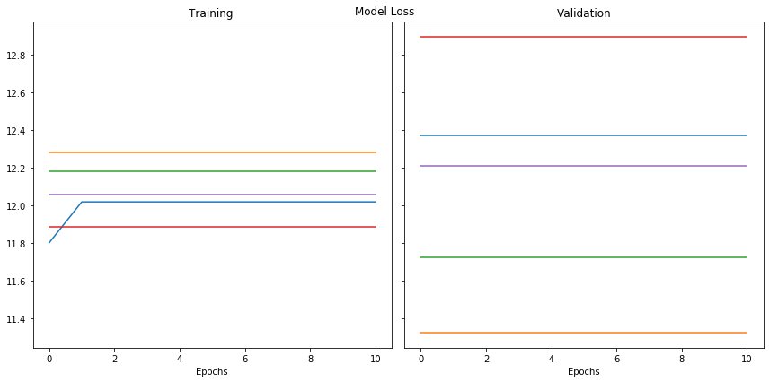

```python
plot_loss(histories_mlp)
```

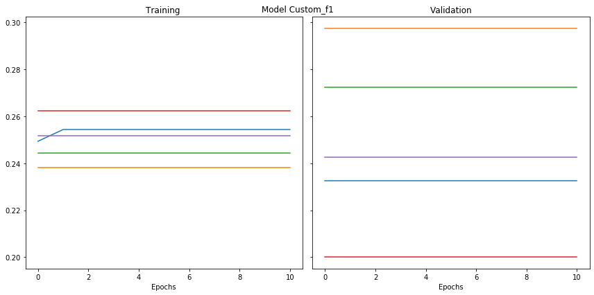

```python
plot_custom_f1(histories_mlp)
```

### CNN1

This cnn architecture was based on the class example.

```python
histories_cnn1 = []

cnn1 = Sequential()
cnn1.add( Conv2D(filters=16, kernel_size= (4, 4), padding='valid',
                 input_shape=(images.shape[1], images.shape[2], images.shape[3]),
                 data_format="channels_last") )
cnn1.add( MaxPooling2D(pool_size=(4, 4), data_format="channels_last") )
cnn1.add( Activation('relu') )
cnn1.add( Flatten() )
cnn1.add( Dense(NUM_CLASSES) )
cnn1.add( Activation('softmax') )

cnn1.compile(loss='categorical_crossentropy', optimizer='rmsprop', metrics=[custom_f1])

for train, test in rs.split(images):
    history = cnn1.fit(x=images[train],
                       y=classifications_ohe[train],
                       validation_data = (images[test], classifications_ohe[test]),
                       batch_size=BATCH_SIZE,
                       epochs=EPOCHS,
                       shuffle=True,
                       callbacks=[EarlyStopping(monitor='val_loss', patience=PATIENCE)])
    histories_cnn1.append(history)

cnn1.summary()
```

```
Train on 1600 samples, validate on 400 samples
Train on 1600 samples, validate on 400 samples
Train on 1600 samples, validate on 400 samples
Train on 1600 samples, validate on 400 samples
Train on 1600 samples, validate on 400 samples
_________________________________________________________________
Layer (type)                 Output Shape              Param #
=================================================================
conv2d (Conv2D)              (None, 397, 397, 16)      784
_________________________________________________________________
max_pooling2d (MaxPooling2D) (None, 99, 99, 16)        0
_________________________________________________________________
activation_1 (Activation)    (None, 99, 99, 16)        0
_________________________________________________________________
flatten_1 (Flatten)          (None, 156816)            0
_________________________________________________________________
dense_4 (Dense)              (None, 4)                 627268
_________________________________________________________________
activation_2 (Activation)    (None, 4)                 0
=================================================================
Total params: 628,052
Trainable params: 628,052
Non-trainable params: 0
_________________________________________________________________
```

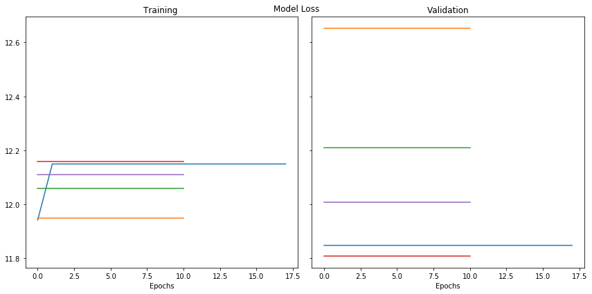

```python
plot_loss(histories_cnn1)
```

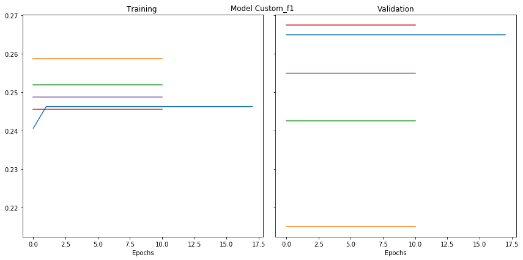

```python
plot_custom_f1(histories_cnn1)
```

## Changing the Architecture

### CNN #2

This model is based on Alexnet. Alexnet is a 8 layer convolutional neural network developed by Alex Krizhevsky. Its main features are the addition of regularization, use of relu and Maxpool. In our version we decrease the number of filters to reduce its computational toll. The kernel sizes are reduced as well.

```python
histories_cnn2 = []

cnn2 = Sequential()
cnn2.add(Conv2D(filters=32, kernel_size=(3, 3), padding='same', input_shape=(images.shape[1], images.shape[2], images.shape[3]), kernel_initializer='he_uniform', activation='relu', data_format="channels_last", kernel_regularizer=l2(0.01)))
cnn2.add(MaxPooling2D(pool_size=(3, 3), data_format="channels_last" ))
cnn2.add(Conv2D(filters=64, kernel_size= (3, 3), padding='same', kernel_initializer='he_uniform', activation='relu', data_format="channels_last", kernel_regularizer=l2(0.01)))
cnn2.add(MaxPooling2D(pool_size=(3, 3), data_format="channels_last" ))
cnn2.add(Conv2D(filters=96, kernel_size= (2, 2), padding='same', kernel_initializer='he_uniform', activation='relu', data_format="channels_last", kernel_regularizer=l2(0.01)))
cnn2.add(Dropout(0.25))
cnn2.add(Conv2D(filters=96, kernel_size= (2, 2), padding='same', kernel_initializer='he_uniform', activation='relu', data_format="channels_last", kernel_regularizer=l2(0.01)))
cnn2.add(Conv2D(filters=64, kernel_size=(2, 2), padding='same', kernel_initializer='he_uniform', activation='relu', data_format="channels_last", kernel_regularizer=l2(0.01)))
cnn2.add(MaxPooling2D(pool_size=(3, 3), data_format="channels_last") )
cnn2.add(Activation('relu') )
cnn2.add(Flatten() )
cnn2.add(Dense(4096, activation='relu', kernel_initializer='he_uniform', kernel_regularizer=l2(0.01)))
cnn2.add(Dropout(0.5))
cnn2.add(Dense(4096, activation='relu', kernel_initializer='he_uniform', kernel_regularizer=l2(0.01)))
cnn2.add(Dropout(0.5))
cnn2.add(Dense(NUM_CLASSES, kernel_initializer='glorot_uniform', kernel_regularizer=l2(0.01), activation='softmax'))

cnn2.compile(loss='categorical_crossentropy', optimizer='rmsprop', metrics=[custom_f1])

for train, test in rs.split(images):

    history2 = cnn2.fit(x=images[train],
                       y=classifications_ohe[train],
                       validation_data = (images[test], classifications_ohe[test]),
                       batch_size=BATCH_SIZE,
                       epochs=EPOCHS,
                       shuffle=True,
                       callbacks=[EarlyStopping(monitor='val_loss', patience=PATIENCE)])
    histories_cnn2.append(history2)

cnn2.summary()
```

```
Train on 1600 samples, validate on 400 samples
Train on 1600 samples, validate on 400 samples
Train on 1600 samples, validate on 400 samples
Train on 1600 samples, validate on 400 samples
Train on 1600 samples, validate on 400 samples
_________________________________________________________________
Layer (type)                 Output Shape              Param #
=================================================================
conv2d_1 (Conv2D)            (None, 400, 400, 32)      896
_________________________________________________________________
max_pooling2d_1 (MaxPooling2 (None, 133, 133, 32)      0
_________________________________________________________________
conv2d_2 (Conv2D)            (None, 133, 133, 64)      18496
_________________________________________________________________
max_pooling2d_2 (MaxPooling2 (None, 44, 44, 64)        0
_________________________________________________________________
conv2d_3 (Conv2D)            (None, 44, 44, 96)        24672
_________________________________________________________________
dropout (Dropout)            (None, 44, 44, 96)        0
_________________________________________________________________
conv2d_4 (Conv2D)            (None, 44, 44, 96)        36960
_________________________________________________________________
conv2d_5 (Conv2D)            (None, 44, 44, 64)        24640
_________________________________________________________________
max_pooling2d_3 (MaxPooling2 (None, 14, 14, 64)        0
_________________________________________________________________
activation_3 (Activation)    (None, 14, 14, 64)        0
_________________________________________________________________
flatten_2 (Flatten)          (None, 12544)             0
_________________________________________________________________
dense_5 (Dense)              (None, 4096)              51384320
_________________________________________________________________
dropout_1 (Dropout)          (None, 4096)              0
_________________________________________________________________
dense_6 (Dense)              (None, 4096)              16781312
_________________________________________________________________
dropout_2 (Dropout)          (None, 4096)              0
_________________________________________________________________
dense_7 (Dense)              (None, 4)                 16388
=================================================================
Total params: 68,287,684
Trainable params: 68,287,684
Non-trainable params: 0
_________________________________________________________________
```

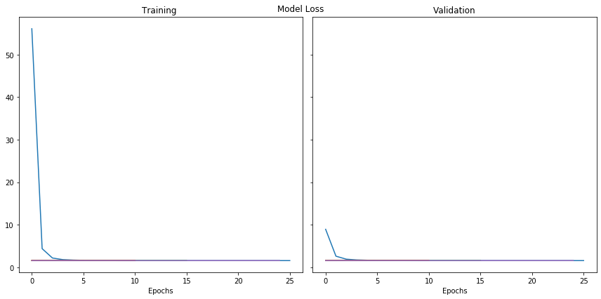

```python
plot_loss(histories_cnn2)
```

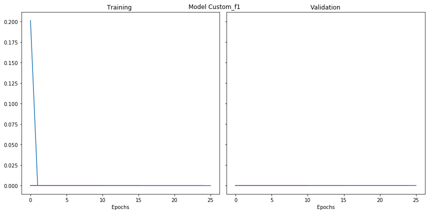

```python
plot_custom_f1(histories_cnn2)
```

### CNN #3

This is a convolutional network with residual layer shamlessly taken from notebook 12.

```python
l2_lambda =0.01
histories_cnn3 = []

input_holder = Input(shape=(images.shape[1], images.shape[2], images.shape[3]))

x = Conv2D(filters=32,
               input_shape = (images.shape[1], images.shape[2], images.shape[3]),
               kernel_size=(3,3),
               kernel_initializer='he_uniform',
               kernel_regularizer=l2(l2_lambda),
               padding='same',
               activation='relu',
               data_format="channels_last")(input_holder)

x = MaxPooling2D(pool_size=(2, 2), data_format="channels_last")(x)

x = Conv2D(filters=32,
               kernel_size=(3,3),
               kernel_initializer='he_uniform',
               kernel_regularizer=l2(l2_lambda),
               padding='same',
               activation='relu',
               data_format="channels_last")(x)

x_split = MaxPooling2D(pool_size=(2, 2), data_format="channels_last")(x)

x = Conv2D(filters=64,
               kernel_size=(1,1),
               kernel_initializer='he_uniform',
               kernel_regularizer=l2(l2_lambda),
               padding='same',
               activation='relu',
               data_format="channels_last")(x_split)

x = Conv2D(filters=64,
               kernel_size=(3,3),
               kernel_initializer='he_uniform',
               kernel_regularizer=l2(l2_lambda),
               padding='same',
               activation='relu',
               data_format="channels_last")(x)

x = Conv2D(filters=32,
               kernel_size=(1,1),
               kernel_initializer='he_uniform',
               kernel_regularizer=l2(l2_lambda),
               padding='same',
               activation='relu',
               data_format="channels_last")(x)

# now add back in the split layer, x_split (residual added in)
x = Add()([x, x_split])
x = Activation("relu")(x)

x = MaxPooling2D(pool_size=(2, 2), data_format="channels_last")(x)

x = Flatten()(x)
x = Dropout(0.25)(x)
x = Dense(256)(x)
x = Activation("relu")(x)
x = Dropout(0.5)(x)
x = Dense(4)(x)
x = Activation('softmax')(x)

cnn3 = Model(inputs=input_holder, outputs=x)
cnn3.compile(loss='categorical_crossentropy', optimizer='rmsprop', metrics=[custom_f1])

for train, test in rs.split(images):

    history3 = cnn3.fit(x=images[train],
                       y=classifications_ohe[train],
                       validation_data = (images[test], classifications_ohe[test]),
                       batch_size=BATCH_SIZE,
                       epochs=EPOCHS,
                       shuffle=True,
                       callbacks=[EarlyStopping(monitor='val_loss', patience=PATIENCE)])
    histories_cnn3.append(history3)

cnn3.summary()
```

```
Train on 1600 samples, validate on 400 samples
Train on 1600 samples, validate on 400 samples
Train on 1600 samples, validate on 400 samples
Train on 1600 samples, validate on 400 samples
Train on 1600 samples, validate on 400 samples
__________________________________________________________________________________________________
Layer (type)                    Output Shape         Param #     Connected to
==================================================================================================
input_1 (InputLayer)            (None, 400, 400, 3)  0
__________________________________________________________________________________________________
conv2d_6 (Conv2D)               (None, 400, 400, 32) 896         input_1[0][0]
__________________________________________________________________________________________________
max_pooling2d_4 (MaxPooling2D)  (None, 200, 200, 32) 0           conv2d_6[0][0]
__________________________________________________________________________________________________
conv2d_7 (Conv2D)               (None, 200, 200, 32) 9248        max_pooling2d_4[0][0]
__________________________________________________________________________________________________
max_pooling2d_5 (MaxPooling2D)  (None, 100, 100, 32) 0           conv2d_7[0][0]
__________________________________________________________________________________________________
conv2d_8 (Conv2D)               (None, 100, 100, 64) 2112        max_pooling2d_5[0][0]
__________________________________________________________________________________________________
conv2d_9 (Conv2D)               (None, 100, 100, 64) 36928       conv2d_8[0][0]
__________________________________________________________________________________________________
conv2d_10 (Conv2D)              (None, 100, 100, 32) 2080        conv2d_9[0][0]
__________________________________________________________________________________________________
add (Add)                       (None, 100, 100, 32) 0           conv2d_10[0][0]
                                                                 max_pooling2d_5[0][0]
__________________________________________________________________________________________________
activation_4 (Activation)       (None, 100, 100, 32) 0           add[0][0]
__________________________________________________________________________________________________
max_pooling2d_6 (MaxPooling2D)  (None, 50, 50, 32)   0           activation_4[0][0]
__________________________________________________________________________________________________
flatten_3 (Flatten)             (None, 80000)        0           max_pooling2d_6[0][0]
__________________________________________________________________________________________________
dropout_3 (Dropout)             (None, 80000)        0           flatten_3[0][0]
__________________________________________________________________________________________________
dense_8 (Dense)                 (None, 256)          20480256    dropout_3[0][0]
__________________________________________________________________________________________________
activation_5 (Activation)       (None, 256)          0           dense_8[0][0]
__________________________________________________________________________________________________
dropout_4 (Dropout)             (None, 256)          0           activation_5[0][0]
__________________________________________________________________________________________________
dense_9 (Dense)                 (None, 4)            1028        dropout_4[0][0]
__________________________________________________________________________________________________
activation_6 (Activation)       (None, 4)            0           dense_9[0][0]
==================================================================================================
Total params: 20,532,548
Trainable params: 20,532,548
Non-trainable params: 0
__________________________________________________________________________________________________
```

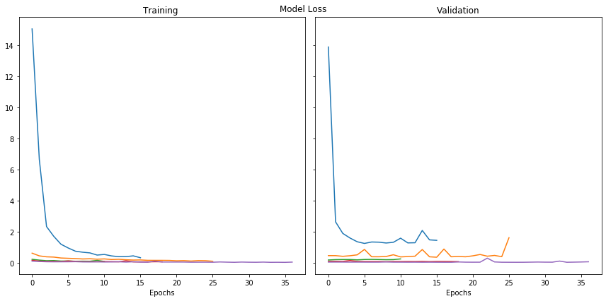

```python
plot_loss(histories_cnn3)
```

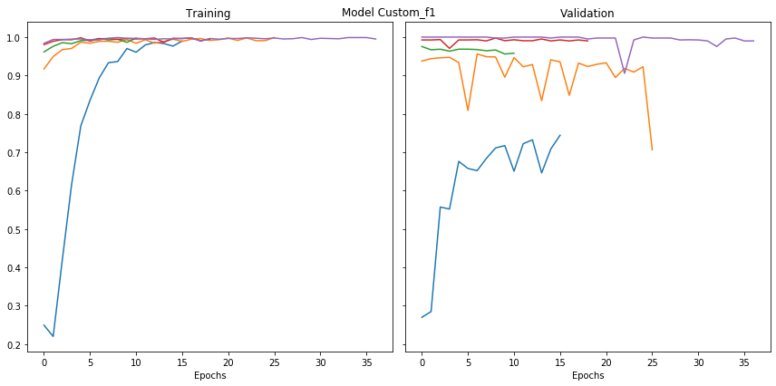

```python
plot_custom_f1(histories_cnn3)
```

# Variations

## CNN2 V.2

```python
histories_cnn2_2 = []

cnn2_2 = Sequential()
cnn2_2.add(Conv2D(filters=32, kernel_size=(11, 11), padding='same', input_shape=(images.shape[1], images.shape[2], images.shape[3]), kernel_initializer='he_uniform', activation='relu', data_format="channels_last", kernel_regularizer=l2(0.01)))
cnn2_2.add(MaxPooling2D(pool_size=(3, 3), data_format="channels_last" ))
cnn2_2.add(Conv2D(filters=64, kernel_size= (5, 5), padding='same', kernel_initializer='he_uniform', activation='relu', data_format="channels_last", kernel_regularizer=l2(0.01)))
cnn2_2.add(MaxPooling2D(pool_size=(3, 3), data_format="channels_last" ))
cnn2_2.add(Conv2D(filters=96, kernel_size= (3, 3), padding='same', kernel_initializer='he_uniform', activation='relu', data_format="channels_last", kernel_regularizer=l2(0.01)))
cnn2_2.add(Dropout(0.25))
cnn2_2.add(Conv2D(filters=96, kernel_size= (3, 3), padding='same', kernel_initializer='he_uniform', activation='relu', data_format="channels_last", kernel_regularizer=l2(0.01)))
cnn2_2.add(Conv2D(filters=64, kernel_size=(3, 3), padding='same', kernel_initializer='he_uniform', activation='relu', data_format="channels_last", kernel_regularizer=l2(0.01)))
cnn2_2.add(MaxPooling2D(pool_size=(3, 3), data_format="channels_last") )
cnn2_2.add(Activation('relu') )
cnn2_2.add(Flatten() )
cnn2_2.add(Dense(128, activation='relu', kernel_initializer='he_uniform', kernel_regularizer=l2(0.01)))
cnn2_2.add(Dropout(0.5))
cnn2_2.add(Dense(128, activation='relu', kernel_initializer='he_uniform', kernel_regularizer=l2(0.01)))
cnn2_2.add(Dropout(0.5))
cnn2_2.add(Dense(NUM_CLASSES, kernel_initializer='glorot_uniform', kernel_regularizer=l2(0.01), activation='softmax'))

cnn2_2.compile(loss='categorical_crossentropy', optimizer='rmsprop', metrics=[custom_f1])

for train, test in rs.split(images):

    history2_2 = cnn2_2.fit(x=images[train],
                       y=classifications_ohe[train],
                       validation_data = (images[test], classifications_ohe[test]),
                       batch_size=BATCH_SIZE,
                       epochs=EPOCHS,
                       shuffle=True,
                       callbacks=[EarlyStopping(monitor='val_loss', patience=PATIENCE)])
    histories_cnn2_2.append(history2_2)

cnn2_2.summary()
```

[output not shown]

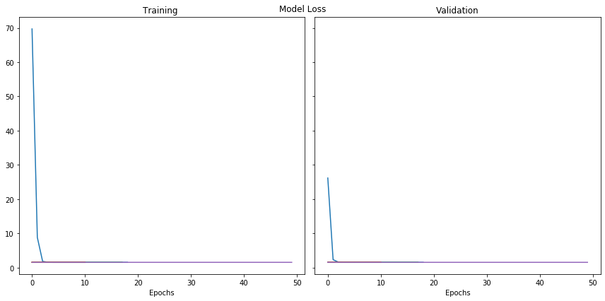

```python
plot_loss(histories_cnn2_2)
```

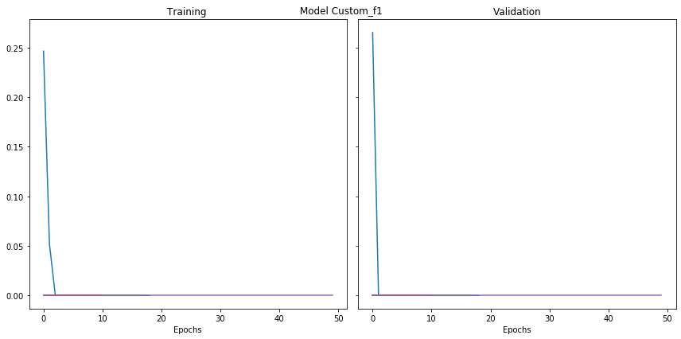

```python
plot_custom_f1(histories_cnn2_2)
```

## CNN3 V.2

In this variation of CNN3 we increase the number of filters in the convolutational layers.

### Due to computational and time constraints we train this network for only one split. Based on previous experience of the CNN3 V.1 we expect this network to train in a similar manner.

```python
classifications_ohe = to_categorical(classifications, NUM_CLASSES)

l2_lambda =0.01
hclassifications_ohe = to_categorical(classifications, NUM_CLASSES)

histories_cnn3_2 = []

input_holder = Input(shape=(images.shape[1], images.shape[2], images.shape[3]))

x = Conv2D(filters=64,
               input_shape = (images.shape[1], images.shape[2], images.shape[3]),
               kernel_size=(3,3),
               kernel_initializer='he_uniform',
               kernel_regularizer=l2(l2_lambda),
               padding='same',
               activation='relu',
               data_format="channels_last")(input_holder)

x = MaxPooling2D(pool_size=(2, 2), data_format="channels_last")(x)

x = Conv2D(filters=128,
               kernel_size=(3,3),
               kernel_initializer='he_uniform',
               kernel_regularizer=l2(l2_lambda),
               padding='same',
               activation='relu',
               data_format="channels_last")(x)

x_split = MaxPooling2D(pool_size=(2, 2), data_format="channels_last")(x)

x = Conv2D(filters=256,
               kernel_size=(1,1),
               kernel_initializer='he_uniform',
               kernel_regularizer=l2(l2_lambda),
               padding='same',
               activation='relu',
               data_format="channels_last")(x_split)

x = Conv2D(filters=128,
               kernel_size=(3,3),
               kernel_initializer='he_uniform',
               kernel_regularizer=l2(l2_lambda),
               padding='same',
               activation='relu',
               data_format="channels_last")(x)

x = Conv2D(filters=128,
               kernel_size=(1,1),
               kernel_initializer='he_uniform',
               kernel_regularizer=l2(l2_lambda),
               padding='same',
               activation='relu',
               data_format="channels_last")(x)

# now add back in the split layer, x_split (residual added in)
x = Add()([x, x_split])
x = Activation("relu")(x)

x = MaxPooling2D(pool_size=(2, 2), data_format="channels_last")(x)

x = Flatten()(x)
x = Dropout(0.25)(x)
x = Dense(256)(x)
x = Activation("relu")(x)
x = Dropout(0.5)(x)
x = Dense(4)(x)
x = Activation('softmax')(x)

cnn3_2 = Model(inputs=input_holder, outputs=x)
cnn3_2.compile(loss='categorical_crossentropy', optimizer='rmsprop', metrics=[custom_f1])

i = 0
for train, test in rs.split(images):
    if i == 0:
        history3_2 = cnn3_2.fit(x=images[train],
                           y=classifications_ohe[train],
                           validation_data = (images[test], classifications_ohe[test]),
                           batch_size=BATCH_SIZE,
                           epochs=EPOCHS,
                           shuffle=True,
                           callbacks=[EarlyStopping(monitor='val_loss', patience=PATIENCE)])
        histories_cnn3_2.append(history3_2)

    else:
        break
    i+=1

cnn3_2.summary()
```

```
Train on 1600 samples, validate on 400 samples
__________________________________________________________________________________________________
Layer (type)                    Output Shape         Param #     Connected to
==================================================================================================
input_3 (InputLayer)            (None, 400, 400, 3)  0
__________________________________________________________________________________________________
conv2d_21 (Conv2D)              (None, 400, 400, 64) 1792        input_3[0][0]
__________________________________________________________________________________________________
max_pooling2d_13 (MaxPooling2D) (None, 200, 200, 64) 0           conv2d_21[0][0]
__________________________________________________________________________________________________
conv2d_22 (Conv2D)              (None, 200, 200, 128 73856       max_pooling2d_13[0][0]
__________________________________________________________________________________________________
max_pooling2d_14 (MaxPooling2D) (None, 100, 100, 128 0           conv2d_22[0][0]
__________________________________________________________________________________________________
conv2d_23 (Conv2D)              (None, 100, 100, 256 33024       max_pooling2d_14[0][0]
__________________________________________________________________________________________________
conv2d_24 (Conv2D)              (None, 100, 100, 128 295040      conv2d_23[0][0]
__________________________________________________________________________________________________
conv2d_25 (Conv2D)              (None, 100, 100, 128 16512       conv2d_24[0][0]
__________________________________________________________________________________________________
add_2 (Add)                     (None, 100, 100, 128 0           conv2d_25[0][0]
                                                                 max_pooling2d_14[0][0]
__________________________________________________________________________________________________
activation_11 (Activation)      (None, 100, 100, 128 0           add_2[0][0]
__________________________________________________________________________________________________
max_pooling2d_15 (MaxPooling2D) (None, 50, 50, 128)  0           activation_11[0][0]
__________________________________________________________________________________________________
flatten_6 (Flatten)             (None, 320000)       0           max_pooling2d_15[0][0]
__________________________________________________________________________________________________
dropout_10 (Dropout)            (None, 320000)       0           flatten_6[0][0]
__________________________________________________________________________________________________
dense_15 (Dense)                (None, 256)          81920256    dropout_10[0][0]
__________________________________________________________________________________________________
activation_12 (Activation)      (None, 256)          0           dense_15[0][0]
__________________________________________________________________________________________________
dropout_11 (Dropout)            (None, 256)          0           activation_12[0][0]
__________________________________________________________________________________________________
dense_16 (Dense)                (None, 4)            1028        dropout_11[0][0]
__________________________________________________________________________________________________
activation_13 (Activation)      (None, 4)            0           dense_16[0][0]
==================================================================================================
Total params: 82,341,508
Trainable params: 82,341,508
Non-trainable params: 0
__________________________________________________________________________________________________
```

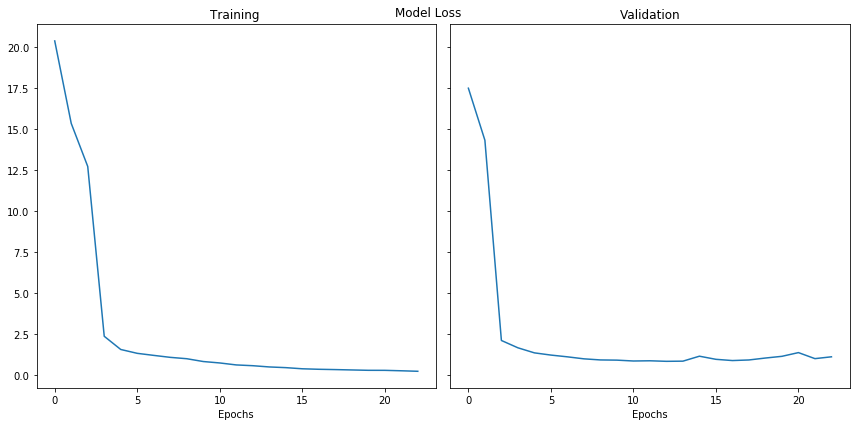

```python
plot_loss(histories_cnn3_2)
```

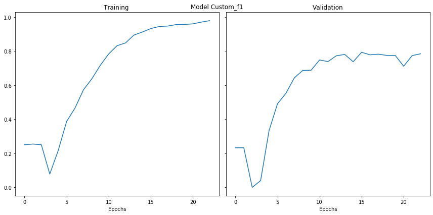

```python
plot_custom_f1(histories_cnn3_2)
```